# Programowe generatory liczb losowych

#### Dawid Żywczak, Seminarium: Algorytmy numeryczne i graficzne.

W tym pliku zobaczymy omawiane przeze mnie metody generowania liczb losowych w akcji oraz przeprowadzimy na nich kilka testów. Postaram się dokładnie opisać parametry przekazywane do funkcji, tak żeby każdy mógł sobie poeksperymentować, do czego bardzo zachęcam. Plik stanowi uzupełnienie do notatek. Rozdziały 1-4 służą przedstawieniu pewnych metod generacji liczb losowych. W rozdziale 5 skupimy się na testowaniu opisanych generatorów w sposób bardziej teoretyczny.

## Spis treści:

1. Generator von Neumanna
2. Generatory liniowe:
   1. Generator multiplikatywny
   2. Generator mieszany
   3. Generator oparty na rejestrach przesuwnych
   4. Generator Fibonacciego
3. Generatory nieliniowe:
   1. Eichenauera-Lehna
   2. Eichenauera-Hermanna
4. Generatory o dowolnym rozkładzie
   1. Rozkład normalny
   2. Rozkład wykładniczy
5. Testy zgodności generatorów:
   1. Test chi-kwadrat
   2. Test Kołmogorowa
   3. Test pokerowy

## 1. Generator von Neumanna

```python
import matplotlib.pyplot as plt
import numpy as np
import time
import random
from scipy import stats
import tqdm
```

```python
def vonNeumann(seed, N, iterations, generated_numbers = [], it = 0):
    '''
    seed - liczba początkowa, determinuje kolejne liczby losowe
    N - długość liczby losowej
    interations - liczba wywołań
    generated_numbers - tablica zawierająca krotki (nr iteracji, wygenerowana liczba)
    iter - licznik iteracji
    '''
    if iterations == 0:
        return generated_numbers
    if N % 2 != 0 and N <= 0:
        print("N musi być parzyste i większe od 0!")
        return
    x = str(seed*seed)
    while(len(x) < 2*N): #wydłużamy liczbę do porządanej wielkości
        x = '0' + x
    z = ''
    i = 0
    mid = len(x)//2
    while(len(z) != N): #skracamy do N środkowych wyrazów
        z = z + x[mid+i]
        z = x[mid-1-i] + z
        i+=1
    z = int(z)
    new_item = [it, z]
    generated_numbers.append(new_item)
    return vonNeumann(z, N, iterations-1, generated_numbers, it+1)
```

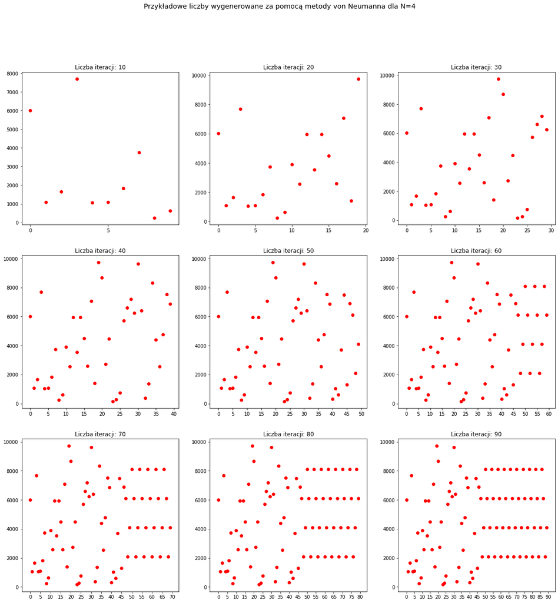

```python
N = 4
iterations = 10
seed = int(time.time())
plot = plt.figure(figsize=(20, 20));
plot.suptitle("Przykładowe liczby wygenerowane za pomocą metody von Neumanna dla N=4", fontsize="x-large")
for i in range(3):
    for j in range(3):
        data = np.matrix(vonNeumann(seed, N, iterations, [], 0))
        subplt = plt.subplot(3, 3, i*3+j+1)
        subplt.set_title("Liczba iteracji: " + str(iterations))
        plt.xticks(list(range(0, iterations+1, 5)))
        iterations+=10
        subplt.scatter([data[:,0]], [data[:,1]], marker='o', color='red')
```

## 2. Generatory liniowe

W tym rozdziale zobaczymy kilka przykładów rozkładów generowanych przez zdefiniowane przez nas generatory liniowe. Zachęcam do sprawdzania różnych parametrów, pozostawiam to jako ćwiczenie :). Warto zauważyć, że małe wartości m nie są zbyt ciekawe, ponieważ nie generują ciągów o odpowiednim okresie (przykład poniżej). Podobna sytuacja dotyczy $a=1$, ponieważ zacyklimy się po jednym kroku.

### Ogólna funkcja używana do generacji

```python
def generate_random_number_mul(a, seed, c, m, N):
    '''
    a - parametr "a" generatora
    seed - X_0 dla pierwszego wywołania
    c - parametr "c" generatora
    m - parametr m generatora
    N - liczba liczb do wygenerowania
    '''
    generated_numbers = list()
    i = 0
    next_item = (a*seed + c) % m
    next_item = [i, next_item]
    generated_numbers.append(next_item)
    i+=1
    while i != N:
        next_item = np.int((a*generated_numbers[i-1][1] + c) % m)
        next_item = [i, next_item]
        generated_numbers.append(next_item)
        i+=1
    return generated_numbers
```

### A. Generator multiplikatywny

Sprawdźmy jak wyglądają wylosowane liczby dla generatorów multiplikatywnych o różnych parametrach, dla tego samego stanu początkowego.

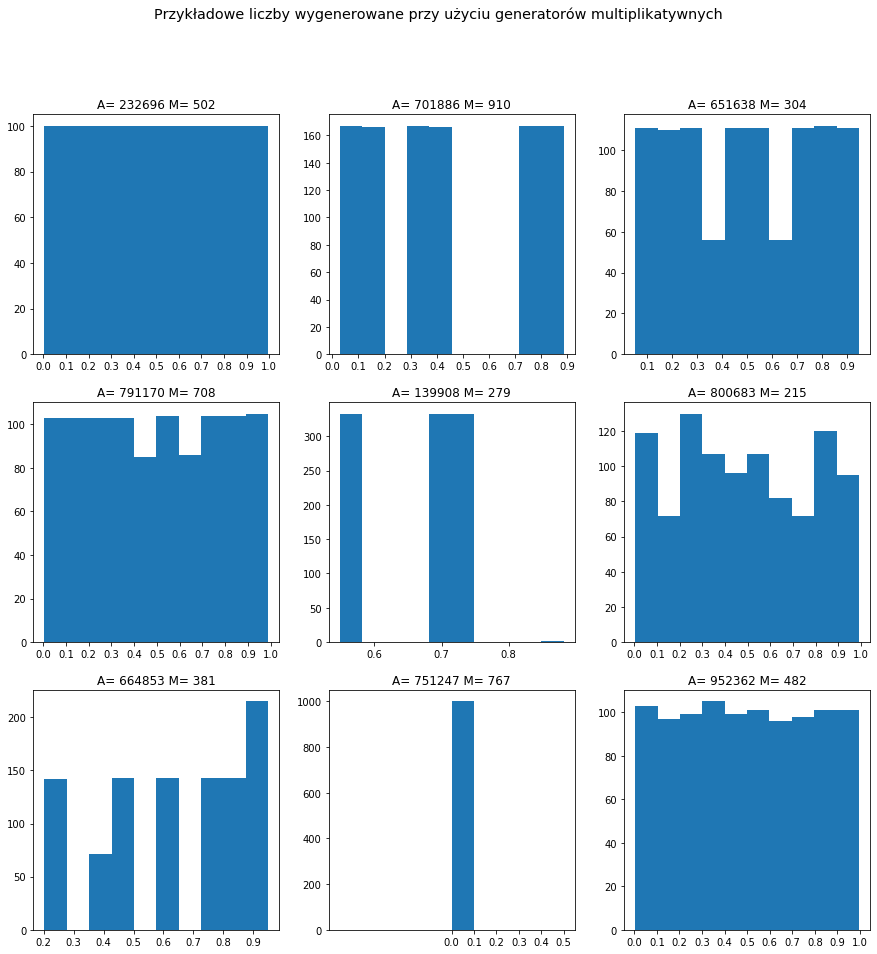

```python
seed = int(time.time())
A = np.random.randint(10000, 2**20, 9)
M = np.random.randint(100, 1000, 9)
pointer = 0
iterations = 1000
seed = int(time.time())
plot = plt.figure(figsize=(15, 15));
plot.suptitle("Przykładowe liczby wygenerowane przy użyciu generatorów multiplikatywnych", fontsize="x-large")
for i in range(3):
    for j in range(3):
        data = np.array(generate_random_number_mul(A[pointer], seed, 0, M[pointer], iterations))
        subplt = plt.subplot(3, 3, i*3+j+1)
        subplt.set_title("A= " + str(A[pointer]) + " M= " + str(M[pointer]))
        plt.xticks(np.arange(0, 1.1, 0.1))
        subplt.hist([data[:,1]/M[pointer]], 10)
        pointer+=1
```

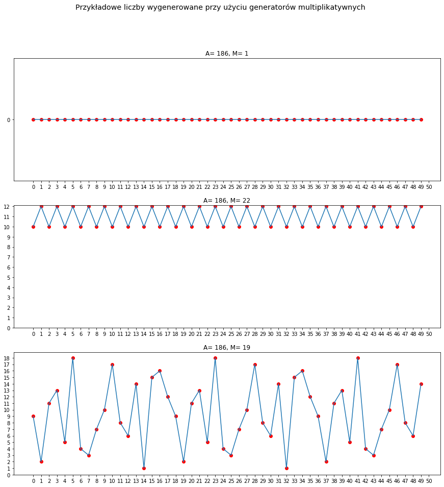

```python
seed=int(time.time())
m = 1
a = np.random.randint(100, 200)
plot = plt.figure(figsize=(15, 15));
plot.suptitle("Przykładowe liczby wygenerowane przy użyciu generatorów multiplikatywnych", fontsize="x-large")
for i in range(3):
        data = np.array(generate_random_number_mul(a, seed, 0, m, 50), dtype=np.int)
        subplt = plt.subplot(3, 1, i+1)
        subplt.set_title("A= " + str(a) + ", M= " + str(m))
        subplt.scatter([data[:,0]], [data[:,1]], marker='o', color='red')
        subplt.plot(data[:,0], data[:,1])
        plt.xticks(np.arange(0, 51))
        plt.yticks(np.arange(0, np.max(data[:,1])+1))
        m = np.random.randint(10, 30)
```

#### Struktura przestrzenna

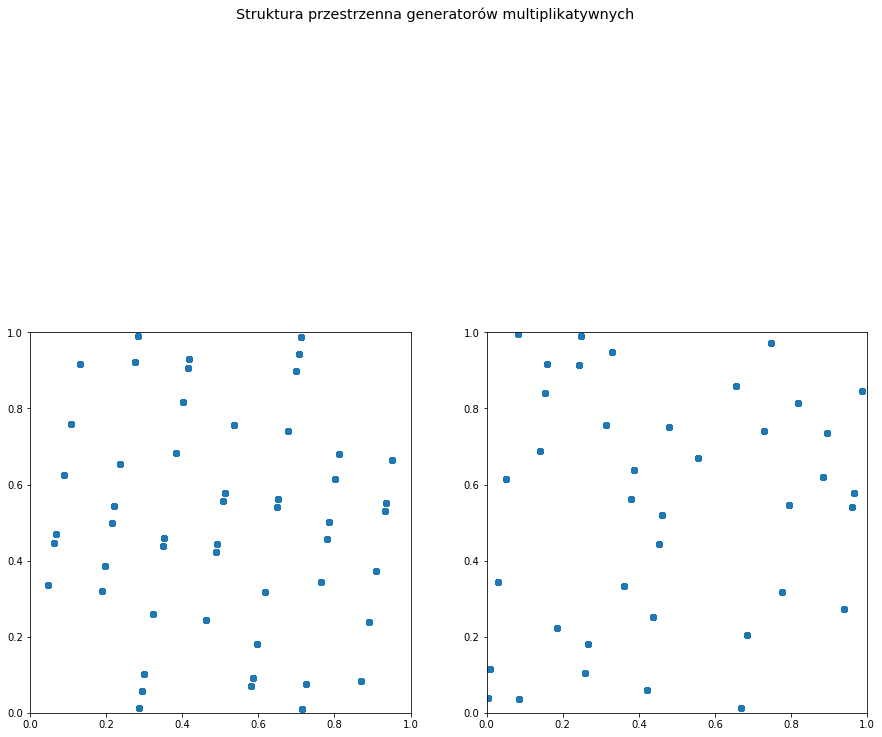

```python
how_many = 10**4
m = 313
seed = int(time.time())
plot = plt.figure(figsize=(15, 15));
plot.suptitle("Struktura przestrzenna generatorów multiplikatywnych", fontsize="x-large")
subplt = plt.subplot(1, 2, 1, autoscale_on=False, aspect='equal')
data = np.array(generate_random_number_mul(7, seed, 0, m, how_many), dtype=np.int)
data = data[:,1].reshape(int(how_many / 2),2)
data = data/m
plt.scatter(data[:,0], data[:,1])
subplt = plt.subplot(1, 2, 2, autoscale_on=False, aspect='equal')
data = np.array(generate_random_number_mul(12, seed, 0, m, how_many), dtype=np.int)
data = data[:,1].reshape(int(how_many / 2),2)
data = data/m
plt.scatter(data[:,0], data[:,1])
plt.show()
```

#### Okresowość ostatnich bitów

```python
how_many = 100
seed = 17
data = np.array(generate_random_number_mul(13, seed, 0, 8, how_many), dtype=np.int32)
data[:,1] = data[:,1]&0x0007
print(data[:,1])
```

```
[5 1 5 1 5 1 5 1 5 1 5 1 5 1 5 1 5 1 5 1 5 1 5 1 5 1 5 1 5 1 5 1 5 1 5 1 5
 1 5 1 5 1 5 1 5 1 5 1 5 1 5 1 5 1 5 1 5 1 5 1 5 1 5 1 5 1 5 1 5 1 5 1 5 1
 5 1 5 1 5 1 5 1 5 1 5 1 5 1 5 1 5 1 5 1 5 1 5 1 5 1]
```

### B. Generator mieszany

W tym podrozdziale zobaczymy jak zachowuje się generator mieszany zaproponowany przez Marsaglię w 1972 roku.

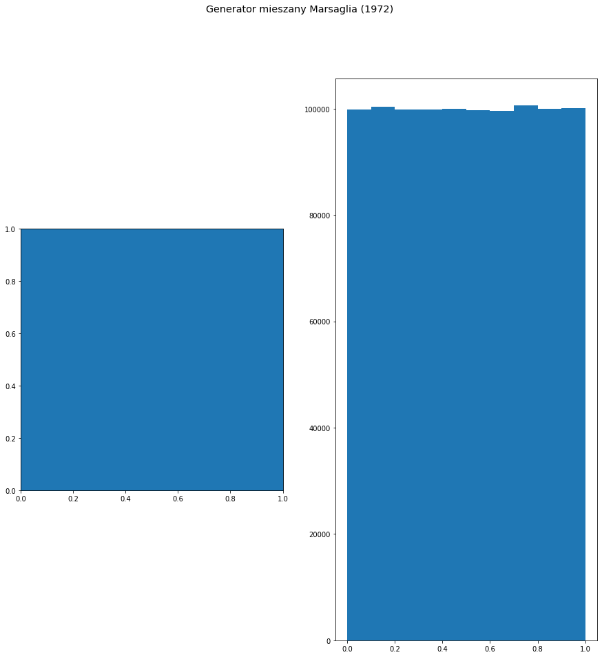

```python
how_many = 10**6 #dla 10^6 liczb otrzymujemy bardzo dobre wypełnienie przedziału (0,1)
seed = int(time.time())
plot = plt.figure(figsize=(15, 15));
plot.suptitle("Generator mieszany Marsaglia (1972)", fontsize="x-large")
subplt = plt.subplot(1, 2, 1, autoscale_on=False, aspect='equal')
data = np.array(generate_random_number_mul(69069, seed, 1, 2**31 - 1, how_many), dtype=np.int)
data = data[:,1].reshape(int(how_many / 2),2)
data = data/(2 ** 31 - 1)
plt.scatter(data[:,0], data[:,1])
subplt = plt.subplot(1, 2, 2)
data = np.array(generate_random_number_mul(69069, seed, 1, 2**31 - 1, how_many), dtype=np.int)
data = data[:,1]/(2 ** 31 - 1)
plt.hist(data)
plt.show()
```

### C. Generator oparty na rejestrach przesuwnych (implementacja z ksiązki [2] str. 38)

Korzysta on z trzech generatorów o okresach $(2^{28} -1), (2^{29}-1)$ i $(2^{31}-1)$. Jego okres to iloczyn okresów poszczególnych generatorów składowych. Jak widać na drugim wykresie, generatory tego typu nie posiada struktury przestrzennej, tak jak generatory multiplikatywne.

```python
def rshift(val, n): return val>>n if val >= 0 else (val+0x100000000)>>n
s1 = np.uint32(100)
s2 = np.uint32(150)
s3 = np.uint32(200)
def initial():
    '''
    s1, s2, s3 - liczby startowa
    '''
    global s1, s2, s3
    B = np.uint32(s1) << np.uint32(9)
    B = np.uint32(B) ^ np.uint32(s1)
    B = np.uint32(B) << np.uint32(4)
    s1 = (np.uint32(s1) <<  4) ^ rshift(np.uint32(B), 28)
    B = np.uint32(s2) << np.uint32(2)
    B = np.uint32(B) ^ np.uint32(s2)
    B = np.uint32(B) << np.uint32(3)
    s2 = (np.uint32(s2) <<  3) ^ rshift(np.uint32(B), 29)
    B = np.uint32(s3) << np.uint32(6)
    B = np.uint32(B) ^ np.uint32(s3)
    B = np.uint32(B) << np.uint32(1)
    s3 = (np.uint32(s3) <<  1) ^ rshift(np.uint32(B), 31)
def tausworth_gen():
    global s1, s2, s3
    b = np.uint32(np.uint32(s1 << 9) ^ s1) << 4
    s1 = np.uint32(s1 << 13) ^ np.uint32(rshift(b, 19))
    b = np.uint32(np.uint32(s2 << 2) ^ s2) << 3
    s2 = np.uint32(s2 << 20) ^ np.uint32(rshift(b, 12))
    b = np.uint32(np.uint32(s3 << 6) ^ s3) << 1
    s3 = np.uint32(s3 << 17) ^ np.uint32(rshift(b, 15))
    return np.double((s1^s2^s3)*2.3283064365e-10)
```

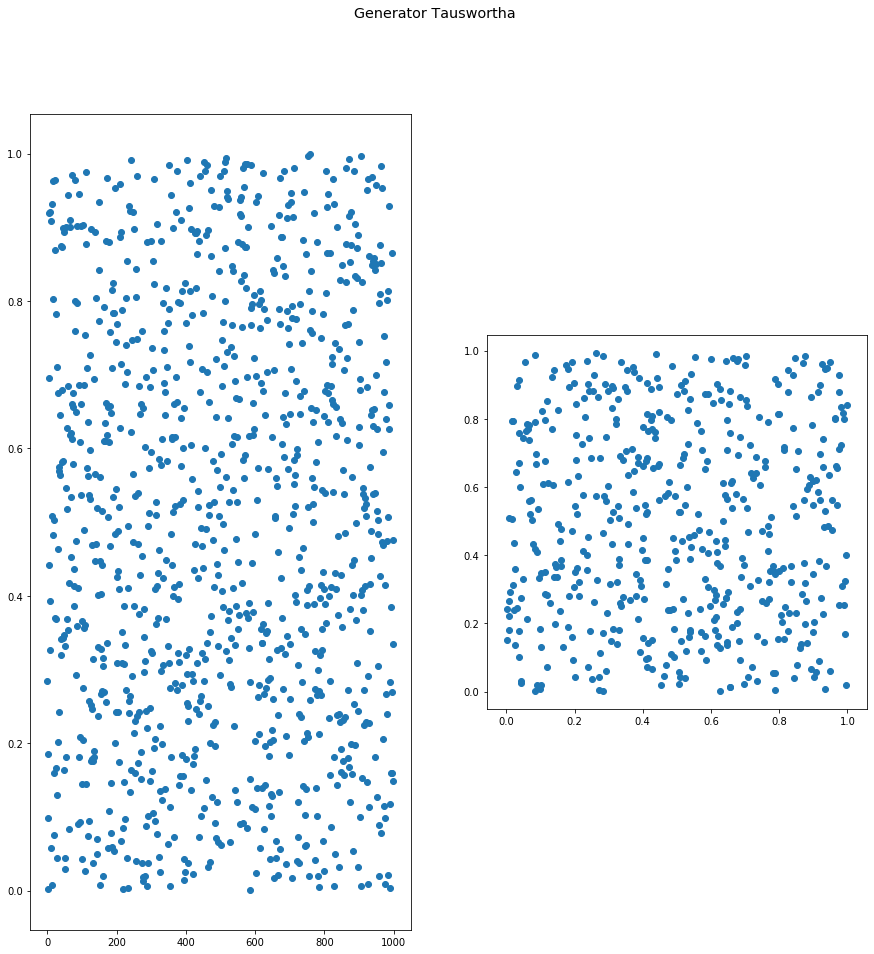

```python
initial()
plot = plt.figure(figsize=(15, 15));
plot.suptitle("Generator Tauswortha", fontsize="x-large")
subplt = plt.subplot(1, 2, 1)
data = []
for i in range(0, 10**3):
    data.append(tausworth_gen())
data = np.array(data)
plt.scatter(np.arange(0, 10**3), data)
subplt = plt.subplot(1, 2, 2, aspect='equal')
data = data.reshape(500, 2)
plt.scatter(data[:,0], data[:,1])
plt.show()
```

### D. Generatory Fibonacciego

Jak widać na pierwszym z poniższych wykresów, ciąg reszt mod m z liczb Fibonacciego sam w sobie jest dosyć dobrym generatorem liczb losowych. Wszystko zależy od wyboru liczby m.

```python
def fib(X0, X1, n, m):
    '''
    X0, X1 - startowe wyrazy
    n - liczba liczb do wygenerowania
    m - modulo
    '''
    generated_numbers = [[1, X0], [2, X1]]
    F1 = X0
    F2 = X1
    for i in range(3, n+1):
        F3 = (F1+F2) % m
        F1 = F2
        F2 = F3
        generated_numbers.append([i, F3])
    return generated_numbers
```

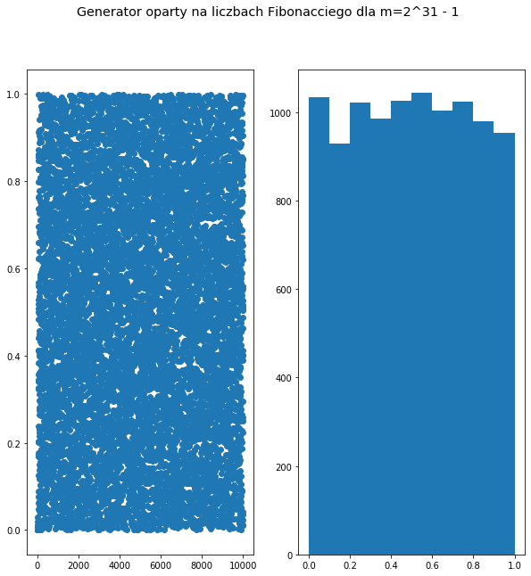

```python
plot = plt.figure(figsize=(10, 10));
plot.suptitle("Generator oparty na liczbach Fibonacciego dla m=2^31 - 1", fontsize="x-large")
data = np.array(fib(1, 1, 10**4, 2**31 - 1))
subplt = plt.subplot(1, 2, 1)
plt.scatter(data[:,0], data[:,1]/(2**31 - 1))
subplt = plt.subplot(1, 2, 2)
plt.hist(data[:,1]/(2**31 - 1))
plt.show()
```

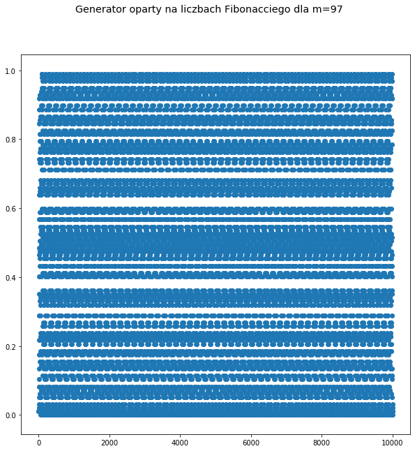

```python
plot = plt.figure(figsize=(10, 10));
plot.suptitle("Generator oparty na liczbach Fibonacciego dla m=97", fontsize="x-large")
data = np.array(fib(1, 1, 10**4, 97))
plt.scatter(data[:,0], data[:,1]/97)
plt.show()
```

## 3. Generatory nieliniowe

Poniżej zamieszczam implementację dwóch omawianych przeze mnie generatorów nieliniowych, oraz kilka wykresów sprawdzające ich własności. Warto zauważyć, że wartości m nie mogą być zbyt duże, ponieważ obliczanie (m-2) potęgi będzie czasochłonne.

### A. Generator Eichenauera-Lehna

Jak widać poniżej, generator dość dobrze przybliża rozkład U(0,1). Można też zauważyć pewną strukutrę dla punktów $(U_i, U_{i+1})$.

```python
def eichenauer_lehn(a, X0, b, m, n):
    '''
    a - mnożnik
    X0 - wyraz początkowy
    b - czynnik dodawany
    m - liczba modulo (musi być pierwsza)
    n - liczba liczb do wygenerowania
    '''
    generated_numbers = []
    for i in tqdm.tqdm(range(0, n)):
        next_x = 0
        if X0 != 0:
            next_x = X0**(m-2)
        X0 = (a*next_x + b) % m
        generated_numbers.append([i, X0])
    return generated_numbers
```

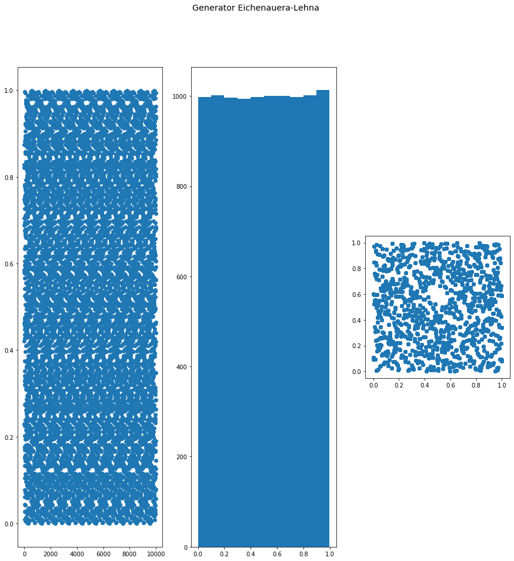

```python
plot = plt.figure(figsize=(15, 15));
plot.suptitle("Generator Eichenauera-Lehna", fontsize="x-large")
data = np.array(eichenauer_lehn(15, int(time.time()), 97, 1031, 10**4))
subplt = plt.subplot(1, 3, 1)
plt.scatter(data[:,0], data[:,1]/1031)
subplt = plt.subplot(1, 3, 2)
plt.hist(data[:,1]/1031)
subplt = plt.subplot(1, 3, 3, aspect='equal')
data = data[:,1].reshape(5000, 2)
plt.scatter(data[:,0]/1031, data[:,1]/1031)
plt.show()
```

### B. Generator Eichenauera-Hermanna

```python
def eichenauer_hermann(a, n0, b, m, n):
    '''
    a - mnożnik
    X0 - wyraz początkowy
    b - czynnik dodawany
    m - liczba modulo (musi być pierwsza)
    n - liczba liczb do wygenerowania
    '''
    generated_numbers = []
    for i in tqdm.tqdm(range(0, n)):
        next_x = 0
        n0 = a*n0+i + b
        if n0 != 0:
            next_x = n0**(m-2)
        n0 = next_x % m
        generated_numbers.append([i, n0])
    return generated_numbers
```

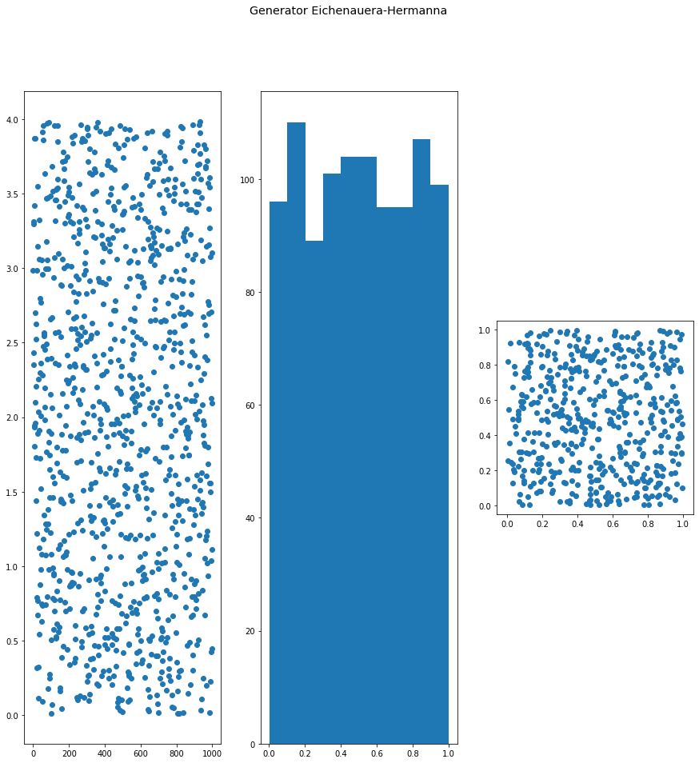

```python
plot = plt.figure(figsize=(15, 15));
plot.suptitle("Generator Eichenauera-Hermanna", fontsize="x-large")
data = np.array(eichenauer_hermann(15, int(time.time()), 0, 4111, 10**3))
subplt = plt.subplot(1, 3, 1)
plt.scatter(data[:,0], data[:,1]/1031)
subplt = plt.subplot(1, 3, 2)
plt.hist(data[:,1]/4111)
subplt = plt.subplot(1, 3, 3, aspect='equal')
data = data[:,1].reshape(500, 2)
plt.scatter(data[:,0]/4111, data[:,1]/4111)
plt.show()
```

## 4. Generatory o dowolnym rozkładzie

W tym rozdziale przedstawię kilka metod przekształcania rozkładu U(0, 1) na inne. W implementacjach użyjemy generatora z biblioteki random. Więcej przykładów można znaleźć w [2] rozdział 3.2.

### A. Rozkład wykładniczy

Najlepszą metodą generowania rozkładu wykładniczego jest metoda odwracania dystrybuatny, dlatego się na niej skupimy. Rozkład wykładniczy $E(\theta, \lambda)$ ma gęstość $f(x)=\frac{1}{\lambda}\exp(-\frac{x-\theta)}{\lambda})$. Jeśli zmienna losowa $Y~E(\theta, \lambda)$ to zmienna $X=(Y-\theta)/\lambda)$ ma rozkład $E(0,1)$, więc skupimy się na generowaniu liczb o takim rozkładzie. Dystrybuanta zmiennej X wyraża się wzorem $F(x)=1-e^{-x}$. Teraz jeśli U ma rozkład jednostajny U(0, 1) to $F^{-1}(x)=-\ln(U)$.

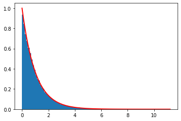

```python
def gen_exp(n, inline=False):
    '''
    n - liczba liczb do wygenerowania
    '''
    generated_numbers = []
    pbar = 0
    if not inline:
        pbar = tqdm.tqdm(total=n)
    for i in range(0, n):
        u = np.random.rand()
        x = -np.log(u)
        generated_numbers.append([i, x])
        if not inline:
            pbar.update(1)
    if not inline:
        pbar.close()
    return generated_numbers
theta = 0
lambd = 1
data = np.array(gen_exp(10**5))[:,1]
count, bins, ignored = plt.hist(data, 100, density=True)
plt.plot(bins, (1/lambd)*np.exp(-((bins-theta)/lambd)),
         linewidth=2, color='r')
plt.show()
```

### B. Rozkład normalny

Rozkład normalny o parametrach $N(\mu, \sigma^2)$ można uzyskać ze zmiennej losowej $X~N(0, 1)$ za pomocą przekształcenia $Y=(X\cdot \sigma) + \mu$.

#### Metoda odwracania dystrybuanty

W notatce wspomniane było, że czasami odwracanie dystrybuanty jest trudne w sensie numerycznym. Tak właśnie jest w tym przypadku, dlatego skorzystamy z przybliżenia funkcji odwrotnej do dystrybuanty N(0,1) podanej przez Odeha I Evansa w 1974 roku.

```python
def gen_norm_cdf(n, inline=False):
    '''
    n - liczba liczb do wygenerowania
    '''
    def horner(x, coefficients):
        result = 0
        for coefficient in coefficients:
            result = result * x + coefficient
        return result
    M_coeffs = [0.0038560700634, 0.103537752850, 0.531103462366, 0.588581570495, 0.0993484626060]
    L_coeffs = [0.0000453642210148, 0.0204231210245, 0.342242088547, 1, 0.322232431088]
    generated_numbers = []
    i = 0
    if not inline:
        pbar = tqdm.tqdm(total=n)
    while i < n:
        u = np.random.rand()
        t = np.sqrt(-2*np.log(u))
        if u > 10**(-20) and u < 0.5:
            g = t - (horner(t, L_coeffs)/horner(t, M_coeffs))
            u = np.random.rand()
            if u > 0.5:
                g=-g
            generated_numbers.append([i, g])
            i+=1
            if not inline:
                pbar.update(1)
        elif u <= 0.5 and u < 1 - 10**(-20):
            g = t - (horner(t, L_coeffs)/horner(t, M_coeffs))
            g = (-1*g)*(1-u)
            u = np.random.rand()
            if u > 0.5:
                g=-g
            generated_numbers.append([i, g])
            i+=1
            if not inline:
                pbar.update(1)
    if not inline:
        pbar.close()
    return generated_numbers
```

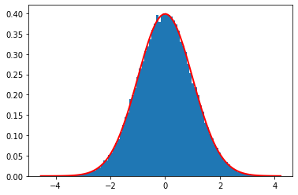

```python
sigma = 1
mu = 0
data = np.array(gen_norm_cdf(10**5))[:,1]
count, bins, ignored = plt.hist(data, 100, density=True)
plt.plot(bins, 1/(sigma * np.sqrt(2 * np.pi)) * np.exp( - (bins - mu)**2 / (2 * sigma**2) ),
         linewidth=2, color='r')
plt.show()
```

#### Metoda eliminacji

Będziemy generować X z dodatniej połowy rozkładu normalnego (gęstość takiego rozkładu to $f(x)=\sqrt{2/\pi}\exp(-x^2/2)$), a następnie z prawdopodobieństwem $p=\frac{1}{2}$ mnożyć razy $-1$. Skorzystamy z rozkładu wykładniczego, który jest łatwo wygenerować, co widzieliśmy wyżej. Niech $g(x)=e^{-x}$ będzie gęstością dominującą. Wtedy nasza stała c to $c=\sqrt{2e/\pi}$.

```python
def gen_norm_elim(n, inline=False):
    '''
    n - liczba liczb do wygenerowania
    '''
    generated_numbers = []
    i = 0
    if not inline:
        pbar = tqdm.tqdm(total=n)
    while i < n:
        while True:
            x = gen_exp(1, inline=True)
            x = x[0][1]
            u = np.random.rand()
            if np.sqrt(2*np.e/np.pi)*u*np.exp(-x) <= np.sqrt(2/np.pi)*np.exp((-1*x*x)/2):
                break
        u = np.random.rand()
        if u >= 0.5:
            x=-x
        generated_numbers.append([i, x])
        i+=1
        if not inline:
            pbar.update(1)
    if not inline:
        pbar.close()
    return generated_numbers
```

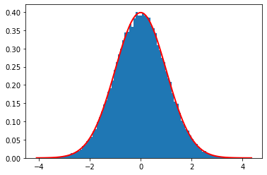

```python
sigma = 1
mu = 0
data = np.array(gen_norm_elim(10**5))[:,1]
count, bins, ignored = plt.hist(data, 100, density=True)
plt.plot(bins, 1/(sigma * np.sqrt(2 * np.pi)) * np.exp( - (bins - mu)**2 / (2 * sigma**2) ),
         linewidth=2, color='r')
plt.show()
```

## 5. Testowanie zgodności generatorów.

W tym rozdziale testować będziemy nasze generatory za pomocą metod omówionych w notatce. Dla testu Kołomogorowa skorzystamy z funkcji bibliotecznych pakietu scipy. Jeżeli testujemy generator dla danego poziomu istotoności $\alpha$, to powinien on nie przechodzić testu średnio raz na $\frac{1}{\alpha}$ przypadków. Taki odsetek niepowodzeń, nie powoduje odrzucenia generatora.

### A. Test chi-kwadrat

```python
def chi_square(data, k=10, sig=0.05):
    '''
    Funkcja oblicza wartość testu chi-kwadrat dla rozkładu jednostajnego na przedziale [0, 1)
    data - wygenerowane liczby
    k - liczba przedziałów
    sig - poziom istotoności testu
    '''
    intervals = np.arange(0, 1.1, 1/k)
    inter = []
    for i in range(k):
        inter.append([intervals[i], intervals[i+1]])
    all_obs = []
    for j in range(0, k):
        x = data[data > inter[j][0]]
        x = x[x <= inter[j][1]]
        all_obs.append(x.shape[0])
    all_obs=np.array(all_obs).reshape(k, 1)
    all_exp = np.zeros([k, 1])
    all_exp[all_exp == 0] = data.shape[0]/k
    chi2_test = (((all_obs-all_exp)**2)/all_exp).sum()
    crit = stats.chi2.ppf(q=1-sig, df=k-1)
    if(chi2_test <= crit):
        return 1
    else:
        return 0
```

```python
#testowanie n=10 prób
for i in range(0, 10):
    data = np.array(generate_random_number_mul(234237, int(time.time()), 0, 105, 10**5))[:,1]/105
    if chi_square(data):
        print("Spełniono test")
    else:
        print("Nie spełniono testu")
```

```
Nie spełniono testu
Nie spełniono testu
Nie spełniono testu
Nie spełniono testu
Nie spełniono testu
Nie spełniono testu
Nie spełniono testu
Nie spełniono testu
Nie spełniono testu
Nie spełniono testu
```

```python
#Testowanie generatora liniowego a=16807, c=0, m=2^32, który powinien przejść testy
zeros = 0
for i in tqdm.tqdm(range(0, 10**3)):
    data = np.array(generate_random_number_mul(16807, int(time.time()), 0, 2**32, 10**5))[:,1]/2**32
    if chi_square(data) == 0:
        zeros+=1.
all_obs=[zeros, 10**3-zeros]
all_obs=np.array(all_obs).reshape(2, 1)
all_exp = np.zeros([2, 1])
all_exp[0] = 0.05*(10**3)
all_exp[1] = 10**3-all_exp[0]
chi2_test = (((all_obs-all_exp)**2)/all_exp).sum()
crit = stats.chi2.ppf(q=1-0.05, df=1)
if(chi2_test <= crit):
    print(1)
else:
    print(0)
```

```
1
```

### B. Test Kołomogorowa

Korzystamy z funkcji bibliotecznej przyjmującej jako argumenty wygenerowane liczby, oraz nazwę rozkładu z którego mają one pochodzić. Wartości zwracane to wartość statystyki oraz wartość p, będąca prawdopodobieństwem tego, że próbka ma podany rozkład.

```python
for i in range(0, 10):
    data = np.array(gen_norm_cdf(10**4, inline=True))[:,1]
    stat, pval = stats.kstest(data, 'norm')
    if pval >= 0.1:
        print("Test spełniony")
    else:
        print("Test nie spełniony")
```

```
Test spełniony
Test spełniony
Test spełniony
Test spełniony
Test spełniony
Test spełniony
Test spełniony
Test spełniony
Test nie spełniony
Test spełniony
```

```python
#Sprawdźmy teraz czy nasze niezależne próby spełniają test chi-kwadrat dla poziomu istotności 0.1
zeros=0
for i in tqdm.tqdm(range(0, 10**3)):
    data = np.array(gen_norm_cdf(10**4, inline=True))[:,1]
    stat, pval = stats.kstest(data, 'norm')
    if pval < 0.1:
        zeros+=1
all_obs=[zeros, 10**3-zeros]
all_obs=np.array(all_obs).reshape(2, 1)
all_exp = np.zeros([2, 1])
all_exp[0] = 0.1*(10**3)
all_exp[1] = 10**3-all_exp[0]
chi2_test = (((all_obs-all_exp)**2)/all_exp).sum()
crit = stats.chi2.ppf(q=1-0.1, df=1)
if(chi2_test <= crit):
    print(1)
else:
    print(0)
```

```
1
```

```python
for i in range(0, 10):
    data = np.array(gen_exp(10**4, inline=True))[:,1]
    stat, pval = stats.kstest(data, 'expon')
    if pval >= 0.1:
        print("Test spełniony")
    else:
        print("Test nie spełniony")
```

```
Test nie spełniony
Test spełniony
Test spełniony
Test spełniony
Test spełniony
Test spełniony
Test spełniony
Test spełniony
Test spełniony
Test spełniony
```

```python
zeros=0
for i in tqdm.tqdm(range(0, 10**3)):
    data = np.array(gen_exp(10**5, inline=True))[:,1]
    stat, pval = stats.kstest(data, 'expon')
    if pval < 0.1:
        zeros+=1
all_obs=[zeros, 10**3-zeros]
all_obs=np.array(all_obs).reshape(2, 1)
all_exp = np.zeros([2, 1])
all_exp[0] = 0.1*(10**3)
all_exp[1] = 10**3-all_exp[0]
chi2_test = (((all_obs-all_exp)**2)/all_exp).sum()
crit = stats.chi2.ppf(q=1-0.1, df=1)
if(chi2_test <= crit):
    print(1)
else:
    print(0)
```

```
1
```

```python
all_obs
```

```
array([[107],
       [893]])
```

### C. Test pokerowy

Zdefinujemy najpierw funkcje prawdopodobieństw odpowiednich piątek, później użyjemy ich do ewaluacji ich rozkładu przy pomocy testu chi-kwadrat

```python
def bust(k):
    if k>=5:
        return ((k-1)*(k-2)*(k-3)*(k-4))/k**4
    else:
        return 0
def pair(k):
    if k>=4:
        return (10*(k-1)*(k-2)*(k-3))/k**4
    else:
        return 0
def double_pair(k):
    if k>=3:
        return (15*(k-1)*(k-2))/k**4
    else:
        return 0
def triple(k):
    if k>=3:
        return (10*(k-1)*(k-2))/k**4
    else:
        return 0
def full(k):
    if k>=3:
        return (10*(k-1))/k**4
    else:
        return 0
def quad(k):
    if k>=2:
        return (5*(k-1))/k**4
    else:
        return 0
def five(k):
    if k>=2:
        return 1/k**4
    else:
        return 0
def identify_tuple(t, k):
    how_many = []
    k = np.arange(0, k)
    for i in k:
        how_many.append(t[t == i].shape[0])
    how_many = np.array(how_many)
    if how_many[how_many == 5].shape[0] == 1:
        return 6
    elif how_many[how_many == 4].shape[0] == 1:
        return 5
    elif how_many[how_many == 3].shape[0] == 1 and how_many[how_many == 2].shape[0] == 1:
        return 4
    elif how_many[how_many == 3].shape[0] == 1:
        return 3
    elif how_many[how_many == 2].shape[0] == 2:
        return 2
    elif how_many[how_many == 2].shape[0] == 1:
        return 1
    elif how_many[how_many == 1].shape[0] == 5:
        return 0
def poker_test(data, k, a, b, sig=0.05):
    '''
    data - próbka wielkości n t.że n % 5 = 0
    k - liczba przedziałów
    [a, b) - przedział wartości zmiennej losowej
    '''
    intervals = np.arange(a, b, 1/k)
    inter = []
    Y = []
    for i in range(k):
        inter.append([intervals[i], intervals[i+1]])
    for i in range(data.shape[0]): #przygotowujemy ciąg Y
        for j in range(k):
            if data[i][0] > inter[j][0] and data[i][0] <= inter[j][1]:
                Y.append(j)
                break
    Y = np.array(Y)
    Y = Y.reshape(data.shape[0]//5, 5)
    Y = np.sort(Y)
    probs = np.array([bust(k), pair(k), double_pair(k), triple(k), full(k), quad(k), five(k)])
    probs*=Y.shape[0]
    all_exp=probs.reshape(7, 1)
    all_obs = np.zeros(7, dtype=np.int)
    for i in Y:
        type_of_tuple = identify_tuple(i, k)
        all_obs[type_of_tuple]+=1
    all_obs = all_obs.reshape(7, 1)
    chi2_test = (((all_obs-all_exp)**2)/all_exp).sum()
    crit = stats.chi2.ppf(q=1-sig, df=k-1)
    if(chi2_test <= crit):
        return 1
    else:
        return 0
```

```python
poker_test(np.random.rand(10000, 1), 10, 0, 1.1)
```

```
1
```

```python
zeros=0
for i in tqdm.tqdm(range(0, 100)):
    result = poker_test(np.random.rand(10**5, 1), 10, 0, 1.1)
    if not result:
        zeros+=1
all_obs=[zeros, 100-zeros]
all_obs=np.array(all_obs).reshape(2, 1)
all_exp = np.zeros([2, 1])
all_exp[0] = 0.05*(100)
all_exp[1] = 100-all_exp[0]
print(all_obs)
print(all_exp)
```

```
[[ 3]
 [97]]
[[ 5.]
 [95.]]
```